# PISA 2012 Data Exploration

## About PISA

The OECD Programme for International Student Assessment (PISA) surveys, which take place every threeyears, have been designed to collect information about 15-year-old students in participating countries. PISA examines how well students are prepared to meet the challenges of the future, rather than how well they master particular curricula.

## Research questions and methodology

Mathematics is an intense subject. Apart from crunching numbers in mind or in calculator, there are various other factors like support from parents and teachers, play an important role in scoring good grades. Not just external support, but how interesting a student find subject, is also of utmost importance. In this document, I will explore the cause and relationship among students scoring mathematics to answer the following questions:

- What is the attitude of students towards scoring high scores in math?
- How parents' education level and occupational status play a role in students’ academia?
- How teachers support their students in advance in their academia?

## Distribution of math score

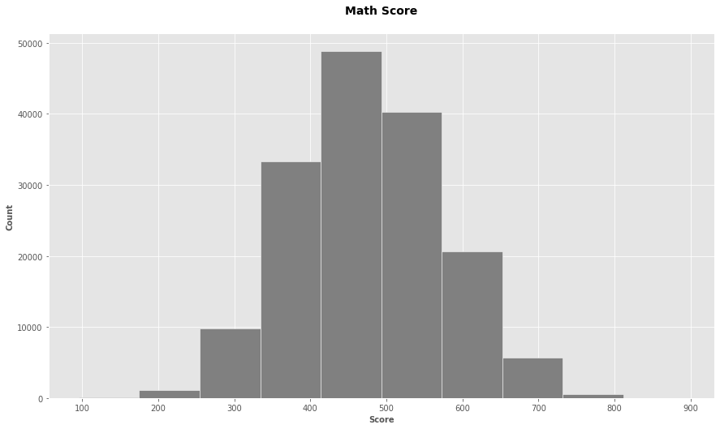

```python
#Plot histogram for math score
plt.figure(figsize=[14.70, 8.27])
plt.hist(df1.math_score, color = 'grey', edgecolor =("white"))
plt.title('Math score'.title(), fontsize = 14, weight = "bold", y = 1.04)
plt.xlabel('score'.title(), fontsize = 10, weight = "bold")
plt.ylabel('count'.title(), fontsize = 10, weight = "bold");
```

The math score is normally distributed which gives a general idea that most students are performing well.

## Gender-wise math score

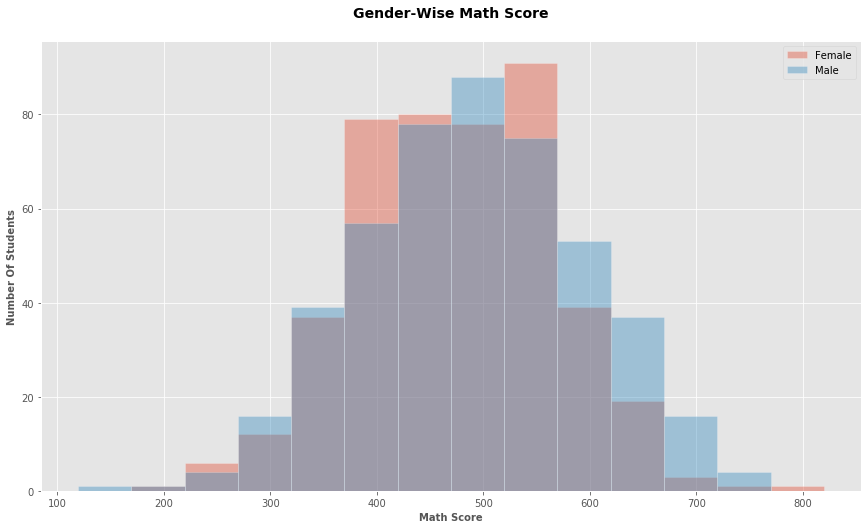

```python
#plot histogram to see gender wise overall math score
binsize=50
bins=np.arange(min(df2_samp['math_score']),max(df2_samp['math_score'])+binsize, binsize)

plt.figure(figsize=[14.70, 8.27])

plt.hist(data=df2_samp.query('gender=="Female"'),x='math_score', alpha=.4,bins=bins,label='Female', edgecolor =("white"))
plt.hist(data=df2_samp.query('gender=="Male"'),x='math_score', alpha=.4,bins=bins, label='Male', edgecolor =("white"))
plt.title('Gender-wise Math Score'.title(), fontsize = 14, weight = "bold", y = 1.04)
plt.xlabel('Math score'.title(), fontsize = 10, weight = "bold")
plt.ylabel('Number of students'.title(),fontsize = 10, weight = "bold")
plt.legend();
```

## Gender wise linear regression between learning time and math score

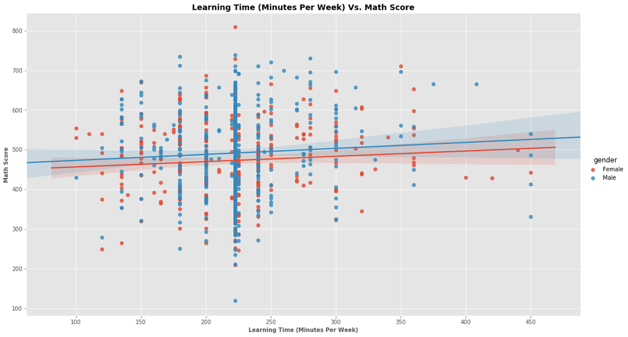

```python
## Plot linear regrression between learning time and math score
g = sns.lmplot(x='learning_time_min',y='math_score', hue = 'gender', data=df2_samp,
               height = 8.27,  aspect = (14.70)/(8.27))
plt.title("Learning time (minutes per week) vs. math score".title(), fontsize = 14, weight = "bold", y = 1.04)
plt.xlabel( 'Learning time (minutes per week)'.title(), fontsize = 10, weight = "bold")
plt.ylabel( 'Math score'.title(), fontsize = 10, weight = "bold");
```

# Correlation matrix

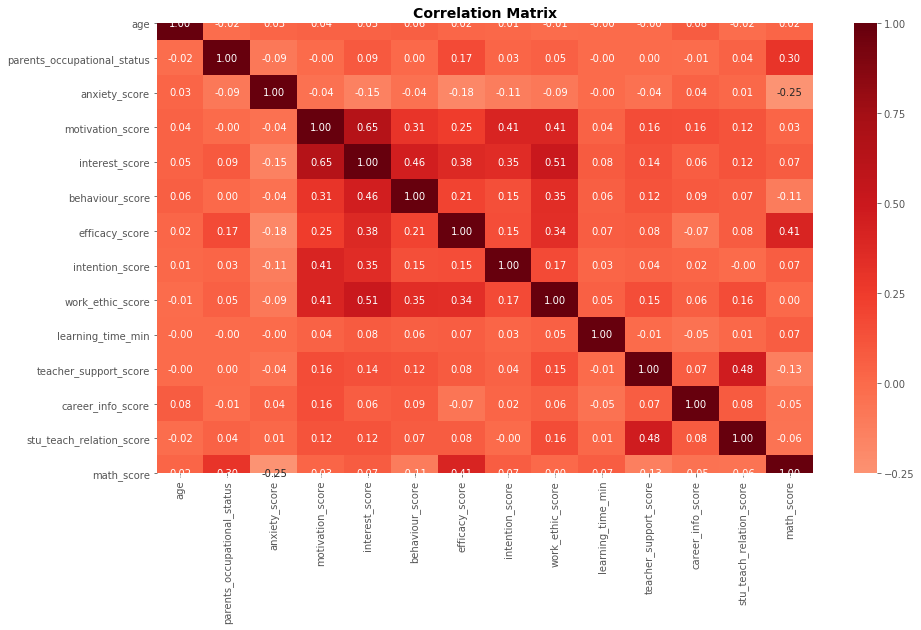

```python
# Plot heatmap to see correlation between 2 variables
plt.figure(figsize=[14.70, 8.27])
sns.heatmap(df2_samp.corr(), annot = True, fmt = '.2f', cmap = 'Reds', center = 0)
plt.title("Correlation Matrix".title(), fontsize = 14, weight = "bold", y = 1.04)
plt.show()
```

## Interaction between parents education level with math score and anxiety score

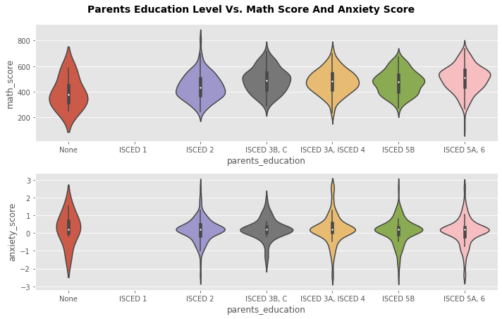

```python
#plot violin plot to see the trend of parents education level with the math score and anxiety score
plt.figure(figsize = [10,6])

# subplot 1: parents occupational status vs parents education
plt.subplot(2, 1, 1)
sns.violinplot(data = df2_samp, y = 'math_score', x = 'parents_education', height = 8.27/2,  aspect = (14.70)/(8.27/2))

# subplot 3: anxiety score vs parents education
ax = plt.subplot(2, 1, 2)
sns.violinplot(data = df2_samp, y = 'anxiety_score', x = 'parents_education', height = 8.27/2,  aspect = (14.70)/(8.27/2))
plt.suptitle("Parents education level vs. math score and anxiety score".title(),fontsize = 14, weight = "bold", y = 1.04)
plt.tight_layout()
plt.show();
```

The median score of the students increases with the increase in education level of their parents. However, the anxiety issues is equally spread out on all education levels which means Sutdent's anxiety levels are not correlated with parents' education levels.

## Relationship between math score and parents occupational status around the world

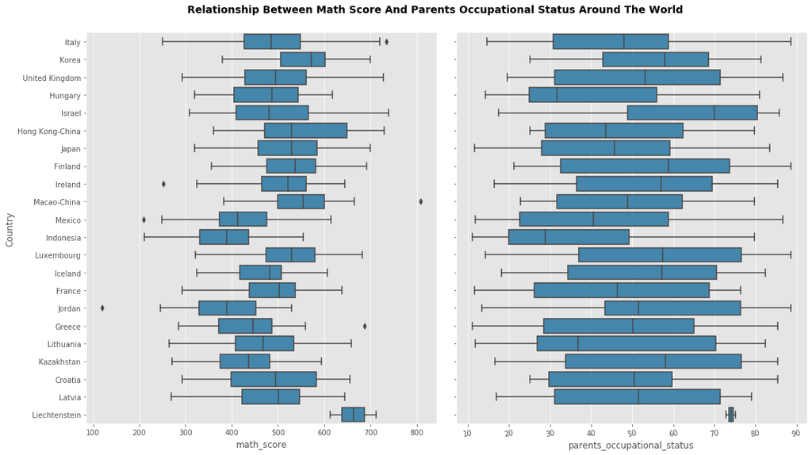

```python
#Create boxplot to compare math score and parents occupation status around the world
def boxgrid(x, y, **kwargs):
    """ Quick hack for creating box plots with seaborn's PairGrid. """
    default_color = sns.color_palette()[1]
    sns.boxplot(x, y, color = default_color)

#plt.figure(figsize = [9, 9])
g = sns.PairGrid(data = df2_samp, x_vars = ['math_score', 'parents_occupational_status'], y_vars = 'Country',
                 height = 8.27,  aspect = (14.70/2)/(8.27))
g.map(boxgrid)
plt.suptitle("Relationship between math score and parents occupational status around the world".title(),
               fontsize = 14, weight = "bold", y = 1.04)
plt.xticks(rotation = 10)
plt.show();
```

The math score is correlated with occupation status of the parents for all the countries except China, Israel, Kazakhstan and Jordan. This means, all over the world, it is seen that parents occupational status has direct impact on students performance.